# Zadania 9

Szymon Szrajer

31 05 2021

## ZADANIE 1

**Hipoteza robocza:** W liniach A wyewoluował wyższy poziom BMR

**Hipoteza zerowa:** Linie A i C mają taki sam poziom BMR

**Hipoteza alternatywna:** W liniach A wyewoluował wyższy poziom BMR

**Model ANOVA:** Y=µ+T+L(T)+ F(L(T))+e

**Założenia:** Niezalezność obserwacji, homogeniczność wariancji, liniowość zależności, normalnośc rozkladu.

```r
vol <- read.delim(file = "Voles_BMR_AC_TLF.txt", header = T, stringsAsFactors = T)
vol$T <- relevel(vol$T, ref = "C")
```

```r
vol %>% group_by(T,L) %>%
  summarise(mean = mean(BMR), median = median(BMR),
            maximum = max(BMR), minimum = min(BMR), sd = sd(BMR), N =  length(BMR))
```

```
## # A tibble: 8 x 8
## # Groups:   T [2]
##   T     L      mean median maximum minimum    sd     N
##   <fct> <fct> <dbl>  <dbl>   <dbl>   <dbl> <dbl> <int>
## 1 C     C1     47.5   47.0    63.3    35    6.49    24
## 2 C     C2     45.8   46.4    51.9    37.6  3.81    24
## 3 C     C3     48.0   47.4    64.5    33.9  8.31    25
## 4 C     C4     48.6   48.7    64      35.2  7.18    23
## 5 A     A1     50.0   48.4    69.9    38.7  8.56    27
## 6 A     A2     48.1   48.1    59.2    37.7  5.19    23
## 7 A     A3     52.9   54.0    73.8    35.5  8.46    26
## 8 A     A4     54.6   55      71.2    37.6  8.31    25
```

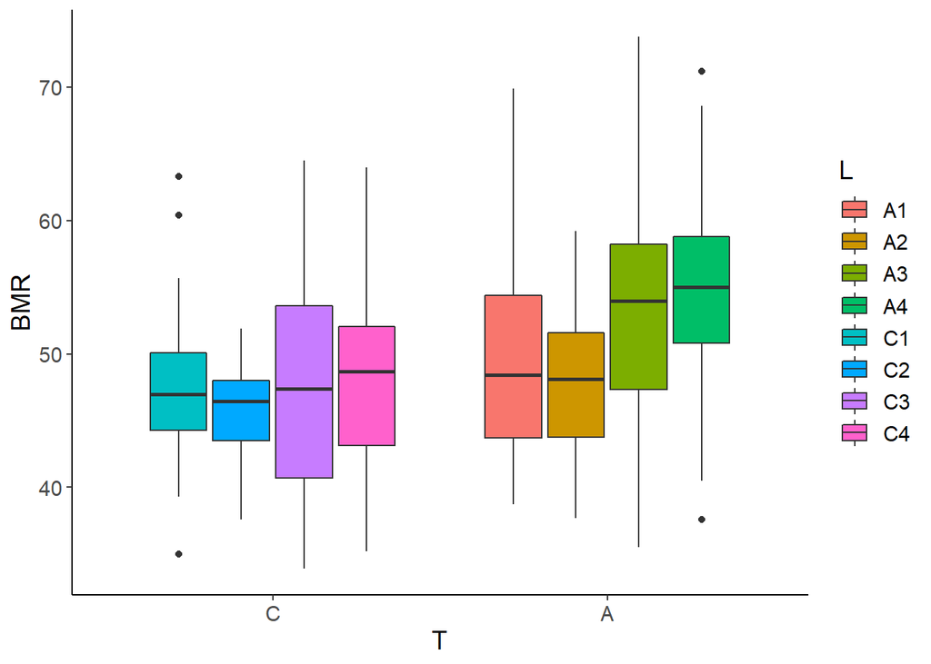

```r
ggplot(data = vol, mapping = aes(x = T, y = BMR, fill = L)) + geom_boxplot() + theme_classic() +
  theme(text = element_text(size = 14))
```

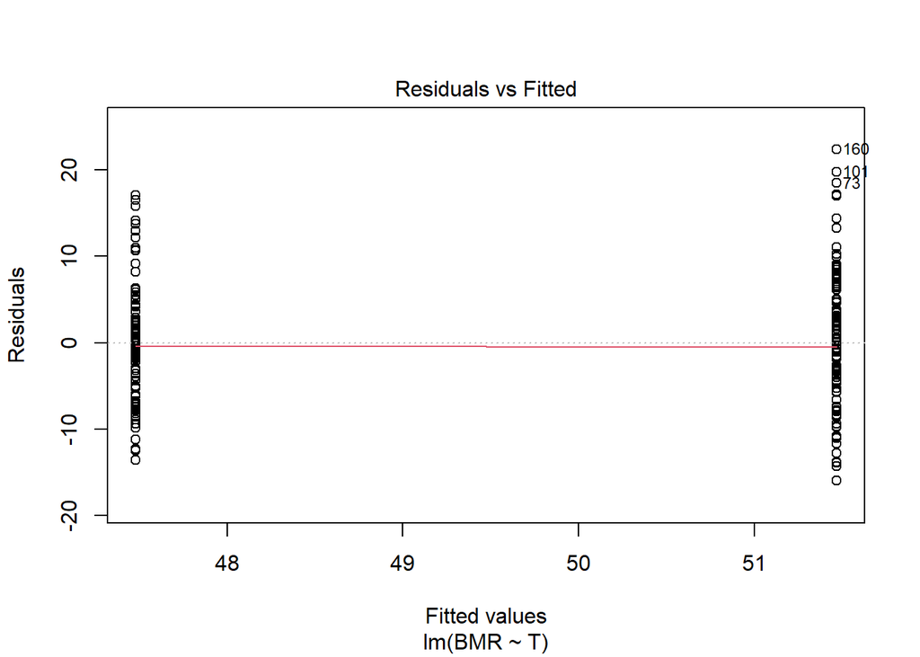

```r
vol_sLm <- lm(BMR ~ T, data = vol)
vol_sAov <- aov(BMR ~ T, data = vol)

plot(vol_sLm,1)
```

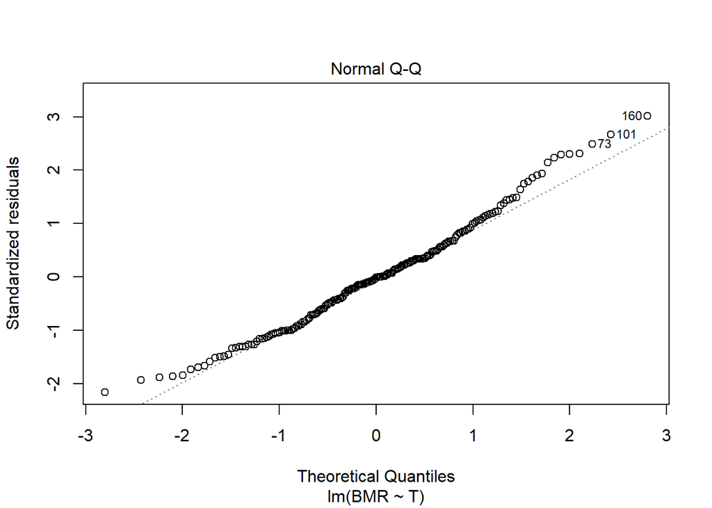

```r
plot(vol_sLm,2)
```

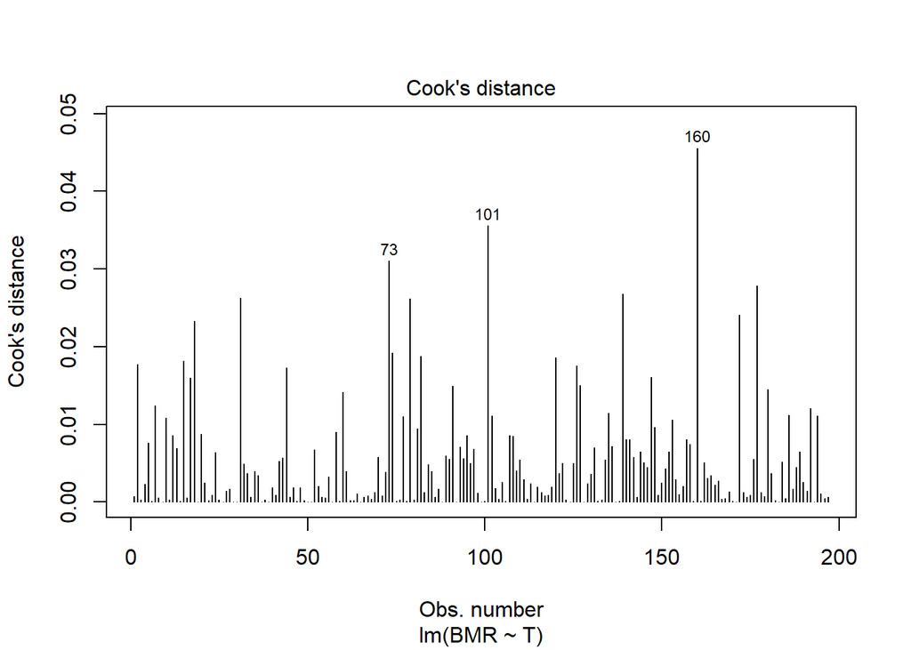

```r
plot(vol_sLm,4)
```

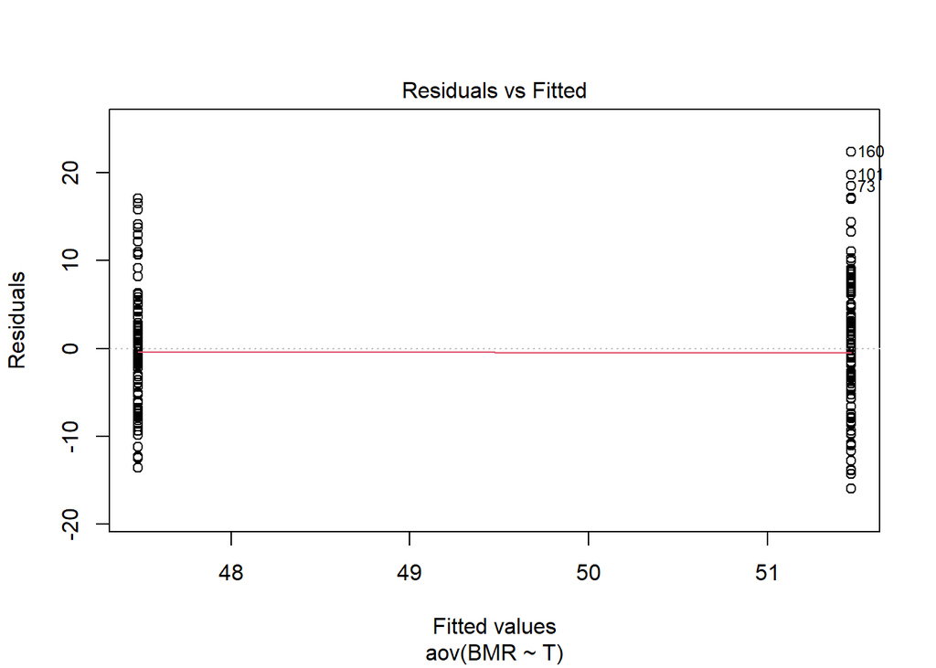

```r
plot(vol_sAov,1)
```

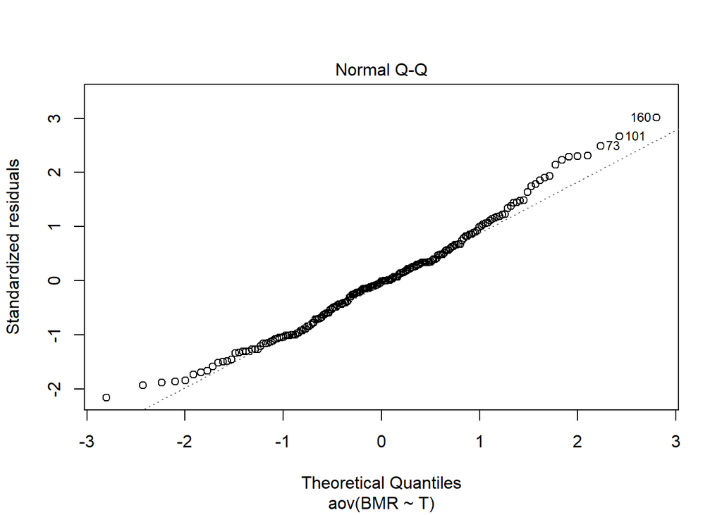

```r
plot(vol_sAov,2)
```

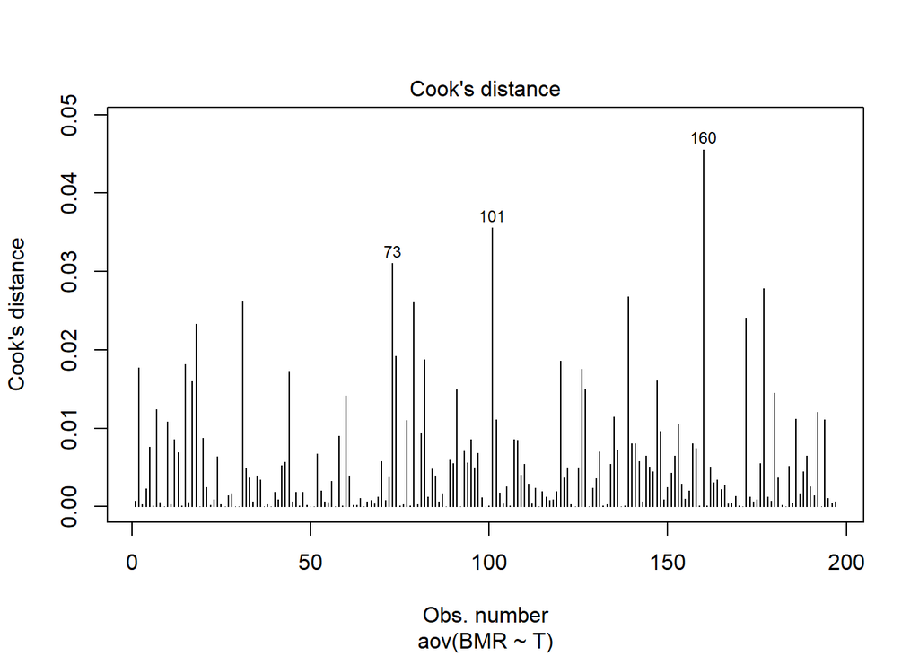

```r
plot(vol_sAov,4)
```

Założenia teoretyczne zostały spełnione. O równości wariancji świadczą rozłożone symetrycznie względem zera wartości resztowe. Rozkład przypomina rozkład normalny. Wykres Cook’s distance wskazuje na brak istotnego wpływu outlayerów na przeprowadzoną analizę.

```r
vol_sLm
```

```
##
## Call:
## lm(formula = BMR ~ T, data = vol)
##
## Coefficients:
## (Intercept)           TA
##      47.479        3.987
```

```r
summary(vol_sLm)
```

```
##
## Call:
## lm(formula = BMR ~ T, data = vol)
##
## Residuals:
##      Min       1Q   Median       3Q      Max
## -15.9663  -5.2792  -0.0792   4.2208  22.3337
##
## Coefficients:
##             Estimate Std. Error t value Pr(>|t|)
## (Intercept)  47.4792     0.7588  62.568  < 2e-16 ***
## TA            3.9872     1.0598   3.762 0.000223 ***
## ---
## Signif. codes:  0 '***' 0.001 '**' 0.01 '*' 0.05 '.' 0.1 ' ' 1
##
## Residual standard error: 7.435 on 195 degrees of freedom
## Multiple R-squared:  0.06767,    Adjusted R-squared:  0.06289
## F-statistic: 14.15 on 1 and 195 DF,  p-value: 0.0002227
```

W grupie referencyjnej wartość średnia to 47,4792, z kolei w TA wynosi 51,466. Otrzymane Pr(>|t|) dla TA jest poniżej 0,05 co wskazuje na oszacowanie istotne statystycznie.

```r
anova(vol_sLm)
```

```
## Analysis of Variance Table
##
## Response: BMR
##            Df  Sum Sq Mean Sq F value    Pr(>F)
## T           1   782.4  782.45  14.154 0.0002227 ***
## Residuals 195 10779.6   55.28
## ---
## Signif. codes:  0 '***' 0.001 '**' 0.01 '*' 0.05 '.' 0.1 ' ' 1
```

Otrzymane Pr(>|t|) jest również istotne statystycznie oraz jego wartość jest równa poprzedniej. Według modelu ANOVA należy odrzucić hipotezę zerową i przyjąć alternatywną: Linie A różnią się od linii C.

```r
vol_sAov
```

```
## Call:
##    aov(formula = BMR ~ T, data = vol)
##
## Terms:
##                         T Residuals
## Sum of Squares    782.449 10779.644
## Deg. of Freedom         1       195
##
## Residual standard error: 7.435067
## Estimated effects may be unbalanced
```

```r
summary(vol_sAov)
```

```
##              Df Sum Sq Mean Sq F value   Pr(>F)
## T             1    782   782.4   14.15 0.000223 ***
## Residuals   195  10780    55.3
## ---
## Signif. codes:  0 '***' 0.001 '**' 0.01 '*' 0.05 '.' 0.1 ' ' 1
```

```r
anova(vol_sAov)
```

```
## Analysis of Variance Table
##
## Response: BMR
##            Df  Sum Sq Mean Sq F value    Pr(>F)
## T           1   782.4  782.45  14.154 0.0002227 ***
## Residuals 195 10779.6   55.28
## ---
## Signif. codes:  0 '***' 0.001 '**' 0.01 '*' 0.05 '.' 0.1 ' ' 1
```

Dla modelu aov uzyskano analogiczne wyniki jak dla modelu lm.  
**Model zagnieżdżony- poziom 1**:

```r
vol_nestedAov <- aov(BMR ~ T + Error(L), data = vol)
vol_nestedLmer <- lmer(BMR ~ T + (1|L), data = vol, REML = T)
```

**Sprawdzenie założeń:**

```r
vol_nestedAov
```

```
##
## Call:
## aov(formula = BMR ~ T + Error(L), data = vol)
##
## Grand Mean: 49.52335
##
## Stratum 1: L
##
## Terms:
##                        T Residuals
## Sum of Squares  782.4487  735.2880
## Deg. of Freedom        1         6
##
## Residual standard error: 11.07014
## Estimated effects are balanced
##
## Stratum 2: Within
##
## Terms:
##                 Residuals
## Sum of Squares   10044.36
## Deg. of Freedom       189
##
## Residual standard error: 7.290044
```

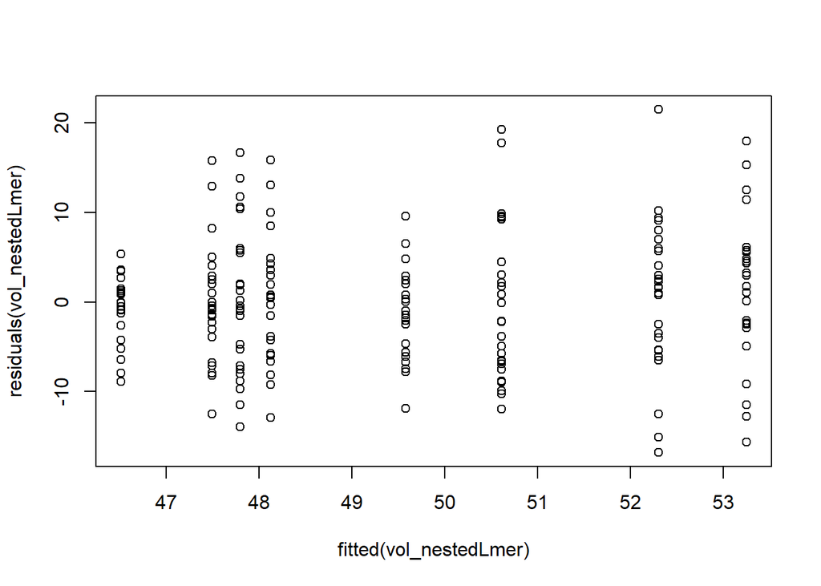

```r
plot(fitted(vol_nestedLmer),residuals(vol_nestedLmer))
```

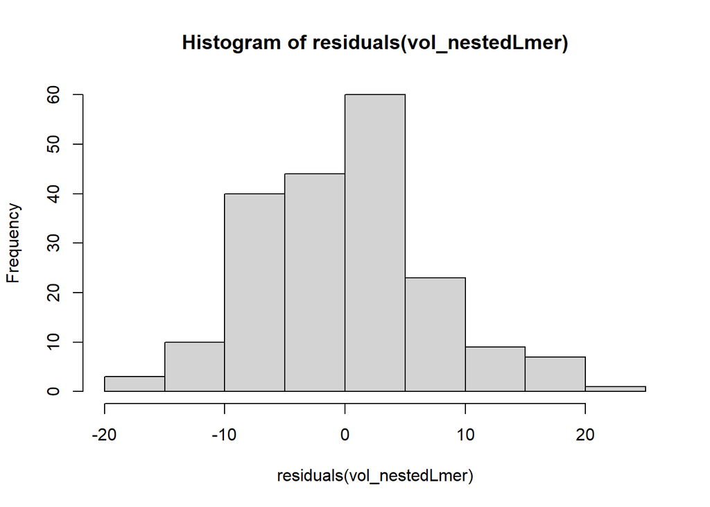

```r
hist(residuals(vol_nestedLmer))
```

Rozkład kształtem zbliżony do normalnego, wartości resztowe symetrycznie rozmieszczone wokół zera.

**Przeprowadzone analizy:**

```r
vol_nestedLmer
```

```
## Linear mixed model fit by REML ['lmerModLmerTest']
## Formula: BMR ~ T + (1 | L)
##    Data: vol
## REML criterion at convergence: 1342.36
## Random effects:
##  Groups   Name        Std.Dev.
##  L        (Intercept) 1.682
##  Residual             7.291
## Number of obs: 197, groups:  L, 8
## Fixed Effects:
## (Intercept)           TA
##      47.483        3.955
```

```r
summary(vol_nestedLmer)
```

```
## Linear mixed model fit by REML. t-tests use Satterthwaite's method [
## lmerModLmerTest]
## Formula: BMR ~ T + (1 | L)
##    Data: vol
##
## REML criterion at convergence: 1342.4
##
## Scaled residuals:
##      Min       1Q   Median       3Q      Max
## -2.30457 -0.72722  0.00287  0.49197  2.94869
##
## Random effects:
##  Groups   Name        Variance Std.Dev.
##  L        (Intercept)  2.828   1.682
##  Residual             53.155   7.291
## Number of obs: 197, groups:  L, 8
##
## Fixed effects:
##             Estimate Std. Error     df t value Pr(>|t|)
## (Intercept)   47.483      1.123  6.058  42.283 1.02e-08 ***
## TA             3.955      1.580  5.928   2.503   0.0468 *
## ---
## Signif. codes:  0 '***' 0.001 '**' 0.01 '*' 0.05 '.' 0.1 ' ' 1
##
## Correlation of Fixed Effects:
##    (Intr)
## TA -0.711
```

Ilość stopni swobody jest teraz inna i wynosi w przybliżeniu 6. Wynika to z faktu szacowania wartości ze względu na oddziaływania między liniami. Wartość współczynnika istotności statystycznej znacznie wzrosła, ale wciąż jest mniejsza niz 0,05, tym samym wyniki są istotne statystycznie.

```r
anova(vol_nestedLmer)
```

```
## Type III Analysis of Variance Table with Satterthwaite's method
##   Sum Sq Mean Sq NumDF  DenDF F value  Pr(>F)
## T 333.12  333.12     1 5.9282  6.2669 0.04679 *
## ---
## Signif. codes:  0 '***' 0.001 '**' 0.01 '*' 0.05 '.' 0.1 ' ' 1
```

Dla modelu anova analogiczne wnioski- wartość parametru istotności statystycznej również zbliżona do 0,05.

```r
rand(vol_nestedLmer)
```

```
## ANOVA-like table for random-effects: Single term deletions
##
## Model:
## BMR ~ T + (1 | L)
##         npar  logLik    AIC    LRT Df Pr(>Chisq)
## <none>     4 -671.18 1350.4
## (1 | L)    3 -672.49 1351.0 2.6264  1     0.1051
```

```r
vol_nestedAov
```

```
##
## Call:
## aov(formula = BMR ~ T + Error(L), data = vol)
##
## Grand Mean: 49.52335
##
## Stratum 1: L
##
## Terms:
##                        T Residuals
## Sum of Squares  782.4487  735.2880
## Deg. of Freedom        1         6
##
## Residual standard error: 11.07014
## Estimated effects are balanced
##
## Stratum 2: Within
##
## Terms:
##                 Residuals
## Sum of Squares   10044.36
## Deg. of Freedom       189
##
## Residual standard error: 7.290044
```

```r
summary(vol_nestedAov)
```

```
##
## Error: L
##           Df Sum Sq Mean Sq F value Pr(>F)
## T          1  782.4   782.4   6.385 0.0449 *
## Residuals  6  735.3   122.5
## ---
## Signif. codes:  0 '***' 0.001 '**' 0.01 '*' 0.05 '.' 0.1 ' ' 1
##
## Error: Within
##            Df Sum Sq Mean Sq F value Pr(>F)
## Residuals 189  10044   53.14
```

Analogiczne wyniki dla aov. Test jest istotny statystycznie. Liczba stopni swobody nie jest tym razem szacowana.

**Wykres wynikowy:**

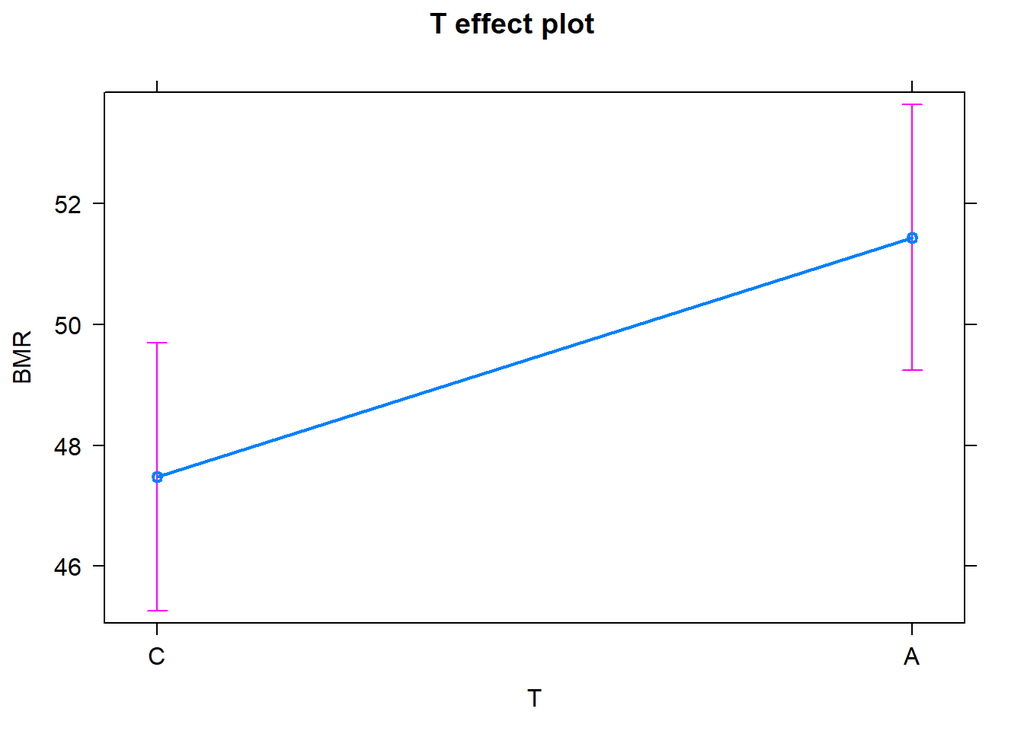

```r
plot(allEffects(vol_nestedLmer))
```

Średnia dla grupy A jest wyższa- zaznaczono przedziały ufności.

**Model wielokrotnie zagnieżdżony:**

```r
vol_multiNested <- lmer(BMR ~ T + (1|L) + (1|F), data = vol, REML = T)
```

**Sprawdzenie założeń:**

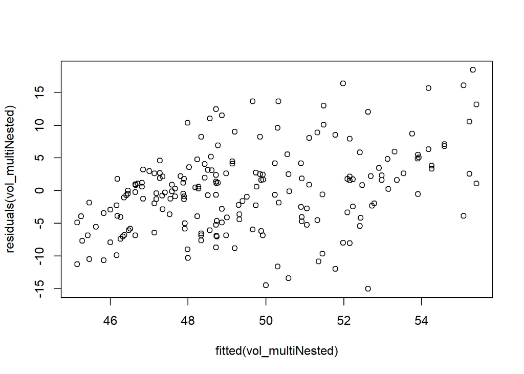

```r
plot(fitted(vol_multiNested),residuals(vol_multiNested))
```

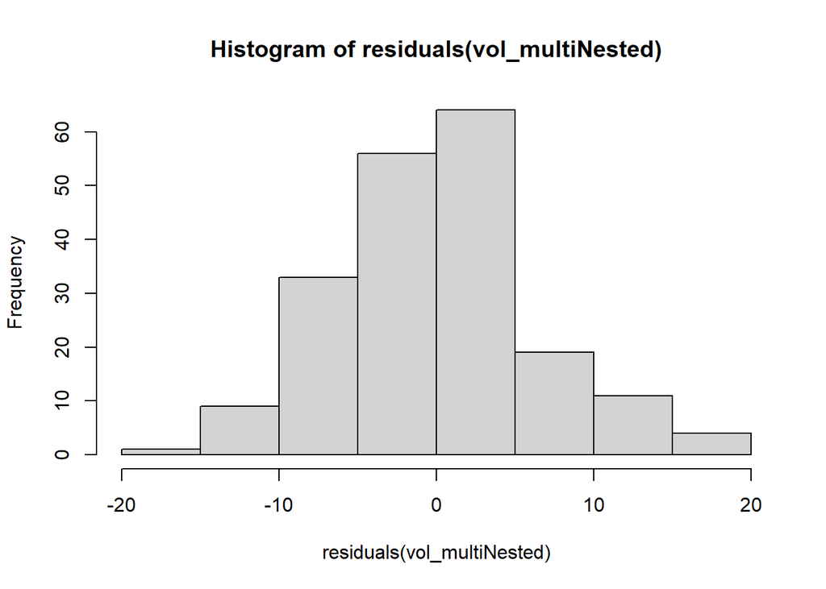

```r
hist(residuals(vol_multiNested))
```

**Przeprowadzone analizy:**

```r
vol_multiNested
```

```
## Linear mixed model fit by REML ['lmerModLmerTest']
## Formula: BMR ~ T + (1 | L) + (1 | F)
##    Data: vol
## REML criterion at convergence: 1341.016
## Random effects:
##  Groups   Name        Std.Dev.
##  F        (Intercept) 2.722
##  L        (Intercept) 1.654
##  Residual             6.775
## Number of obs: 197, groups:  F, 129; L, 8
## Fixed Effects:
## (Intercept)           TA
##      47.458        3.972
```

```r
summary(vol_multiNested)
```

```
## Linear mixed model fit by REML. t-tests use Satterthwaite's method [
## lmerModLmerTest]
## Formula: BMR ~ T + (1 | L) + (1 | F)
##    Data: vol
##
## REML criterion at convergence: 1341
##
## Scaled residuals:
##      Min       1Q   Median       3Q      Max
## -2.21769 -0.61010 -0.01262  0.45657  2.72747
##
## Random effects:
##  Groups   Name        Variance Std.Dev.
##  F        (Intercept)  7.411   2.722
##  L        (Intercept)  2.734   1.654
##  Residual             45.899   6.775
## Number of obs: 197, groups:  F, 129; L, 8
##
## Fixed effects:
##             Estimate Std. Error     df t value Pr(>|t|)
## (Intercept)   47.458      1.136  6.087  41.782 1.02e-08 ***
## TA             3.972      1.597  5.949   2.487   0.0477 *
## ---
## Signif. codes:  0 '***' 0.001 '**' 0.01 '*' 0.05 '.' 0.1 ' ' 1
##
## Correlation of Fixed Effects:
##    (Intr)
## TA -0.711
```

Obserwujemy sytuację jak poprzednio wartość parametru Pr(>|t|) jest mniejsza niż 0,05.

```r
anova(vol_multiNested)
```

```
## Type III Analysis of Variance Table with Satterthwaite's method
##   Sum Sq Mean Sq NumDF  DenDF F value  Pr(>F)
## T 283.84  283.84     1 5.9494  6.1839 0.04771 *
## ---
## Signif. codes:  0 '***' 0.001 '**' 0.01 '*' 0.05 '.' 0.1 ' ' 1
```

Anova pokazuje oszacowanie wariancji. Pr(>|t|) jest bardzo zbliżone do poprzedniego.

```r
rand(vol_multiNested)
```

```
## ANOVA-like table for random-effects: Single term deletions
##
## Model:
## BMR ~ T + (1 | L) + (1 | F)
##         npar  logLik    AIC    LRT Df Pr(>Chisq)
## <none>     5 -670.51 1351.0
## (1 | L)    4 -671.58 1351.2 2.1421  1     0.1433
## (1 | F)    4 -671.18 1350.4 1.3443  1     0.2463
```

Tabela przedstawia wyniki oceny istotności czynników losowych linii i rodzin. Wariancja pomiędzy liniami nie jest duża. Wartości LogLic oraz AIC nie różnią się znacznie. Parametr istotności statystycznej jest większy niż 0,05- rozkład zgodny z rozkładem chi-kwadrat.

**Wykres wynikowy:**

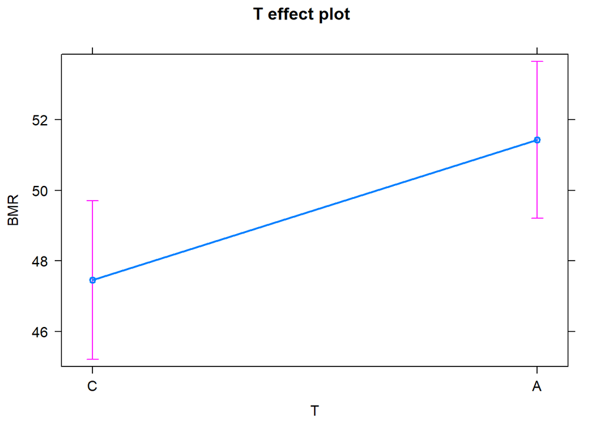

```r
plot(allEffects(vol_multiNested))
```

W linii A jest większy poziom BMR. Zaznaczono przedziały ufności.

## ZADANIE 2

**Hipoteza robocza:** Nowatorski nawóz prowadzi do wzrostu większych truskawek.

**Hipoteza zerowa:** Nowatorski nawóz nie prowadzi do wzrostu większych truskawek.

**Hipoteza alternatywna:** Nowatorski nawóz prowadzi do wzrostu większych truskawek.

**Model ANOVA:** Y = μ + Fertilizer + P + Fertilizer∗P + e

**Założenia:** Niezalezność obserwacji, homogeniczność wariancji, liniowość zależności, normalnośc rozkladu.

```r
strawberries <- read.delim(file = "Strawberries_5plots.txt",header = T, stringsAsFactors = T)

strawberries %>% group_by(Fertilizer,P) %>%
  summarise(mean = mean(M), median = median(M),
            maximum = max(M), minimum = min(M), sd = sd(M), N =  length(M))
```

```
## # A tibble: 10 x 8
## # Groups:   Fertilizer [2]
##    Fertilizer P      mean median maximum minimum    sd     N
##    <fct>      <fct> <dbl>  <dbl>   <dbl>   <dbl> <dbl> <int>
##  1 Novel      P1    14.5   14.4     18.1   10.5   1.87    20
##  2 Novel      P2    13.4   13.5     16.1   11.0   1.59    20
##  3 Novel      P3    13.4   13.4     15.9    9.62  1.63    20
##  4 Novel      P4    12.8   12.9     16.1    8.93  1.84    20
##  5 Novel      P5    13.8   13.7     17.3   10.8   1.74    20
##  6 Old        P1    10.1   10.1     12.5    6.78  1.46    20
##  7 Old        P2    11.1   11.2     13.4    9.05  1.47    20
##  8 Old        P3     9.95   9.46    13.4    7.36  1.85    20
##  9 Old        P4    10.4   10.3     14.6    6.57  2.34    20
## 10 Old        P5    10.4   10.6     12.7    4.43  1.86    20
```

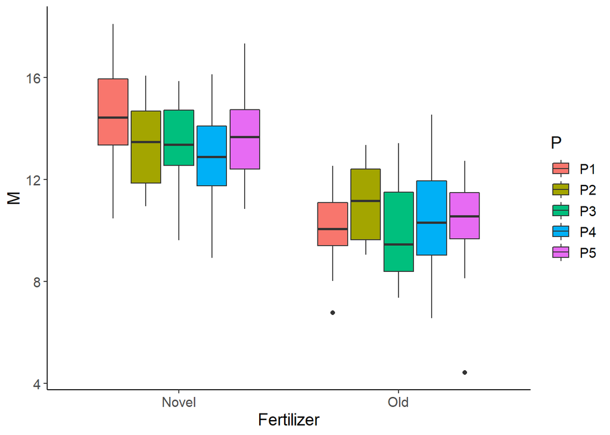

```r
ggplot(data = strawberries, mapping = aes(x = Fertilizer, y = M, fill = P)) + geom_boxplot() + theme_classic() +
  theme(text = element_text(size = 14))
```

```r
strawberries_lmer <- lmer(M ~ Fertilizer + (1|P) + (1|Fertilizer:P), data = strawberries, REML = T)
```

```
## boundary (singular) fit: see ?isSingular
```

**Sprawdzenie założeń:**

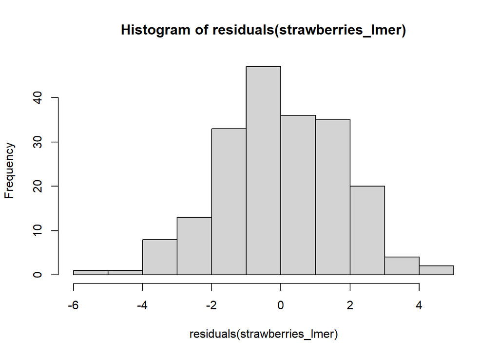

```r
hist(residuals(strawberries_lmer))
```

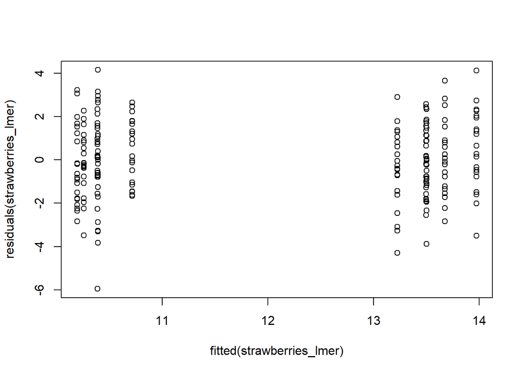

```r
plot(fitted(strawberries_lmer), residuals(strawberries_lmer))
```

Rozkład wartości resztowych przypomina kształtem rozkład normalny. Wartości resztowe symetrycznie rozmieszczone względem zera- wariancja homogeniczna.

**Przeprowadzone analizy:**

```r
strawberries_lmer
```

```
## Linear mixed model fit by REML ['lmerModLmerTest']
## Formula: M ~ Fertilizer + (1 | P) + (1 | Fertilizer:P)
##    Data: strawberries
## REML criterion at convergence: 804.8949
## Random effects:
##  Groups       Name        Std.Dev.
##  Fertilizer:P (Intercept) 0.3593
##  P            (Intercept) 0.0000
##  Residual                 1.7831
## Number of obs: 200, groups:  Fertilizer:P, 10; P, 5
## Fixed Effects:
##   (Intercept)  FertilizerOld
##        13.574         -3.185
## optimizer (nloptwrap) convergence code: 0 (OK) ; 0 optimizer warnings; 1 lme4 warnings
```

```r
summary(strawberries_lmer)
```

```
## Linear mixed model fit by REML. t-tests use Satterthwaite's method [
## lmerModLmerTest]
## Formula: M ~ Fertilizer + (1 | P) + (1 | Fertilizer:P)
##    Data: strawberries
##
## REML criterion at convergence: 804.9
##
## Scaled residuals:
##     Min      1Q  Median      3Q     Max
## -3.3407 -0.6645 -0.0365  0.7423  2.3322
##
## Random effects:
##  Groups       Name        Variance Std.Dev.
##  Fertilizer:P (Intercept) 0.1291   0.3593
##  P            (Intercept) 0.0000   0.0000
##  Residual                 3.1795   1.7831
## Number of obs: 200, groups:  Fertilizer:P, 10; P, 5
##
## Fixed effects:
##               Estimate Std. Error      df t value Pr(>|t|)
## (Intercept)    13.5740     0.2400  8.0000  56.550 1.06e-11 ***
## FertilizerOld  -3.1849     0.3395  8.0000  -9.382 1.36e-05 ***
## ---
## Signif. codes:  0 '***' 0.001 '**' 0.01 '*' 0.05 '.' 0.1 ' ' 1
##
## Correlation of Fixed Effects:
##             (Intr)
## FertilzrOld -0.707
## optimizer (nloptwrap) convergence code: 0 (OK)
## boundary (singular) fit: see ?isSingular
```

Z wyników analizy można odczytać oszacowanie wartości średniej dla grupy referencyjnej- nowatorskiego nawozu. Można też zauważyć wartość współczynnika regresji Pr(>|t|) jest skrajnie mała - występują różnice między masą dla dwóch rodzajów nawozu.

```r
anova(strawberries_lmer)
```

```
## Type III Analysis of Variance Table with Satterthwaite's method
##            Sum Sq Mean Sq NumDF DenDF F value    Pr(>F)
## Fertilizer 279.87  279.87     1     8  88.025 1.364e-05 ***
## ---
## Signif. codes:  0 '***' 0.001 '**' 0.01 '*' 0.05 '.' 0.1 ' ' 1
```

Anova pokazuje oszacowanie wariancji Pr(>|t|) jest istotne statystycznie i bardzo zbliżone do poprzedniego.

```r
rand(strawberries_lmer)
```

```
## ANOVA-like table for random-effects: Single term deletions
##
## Model:
## M ~ Fertilizer + (1 | P) + (1 | Fertilizer:P)
##                    npar  logLik    AIC    LRT Df Pr(>Chisq)
## <none>                5 -402.45 814.89
## (1 | P)               4 -402.45 812.89 0.0000  1     1.0000
## (1 | Fertilizer:P)    4 -403.20 814.41 1.5128  1     0.2187
```

Wartość parametru istotności jest znacznie większa niż 0,05. Rozkład jest zgodny z rozkładem chi-kwadrat- wariancja między poletkami nie ma wpływu na analizę. Wartości LogLik i AIC po usunięciu poletek nie różnią się znacznie względem poprzednich wyników.

**Wykres wynikowy:**

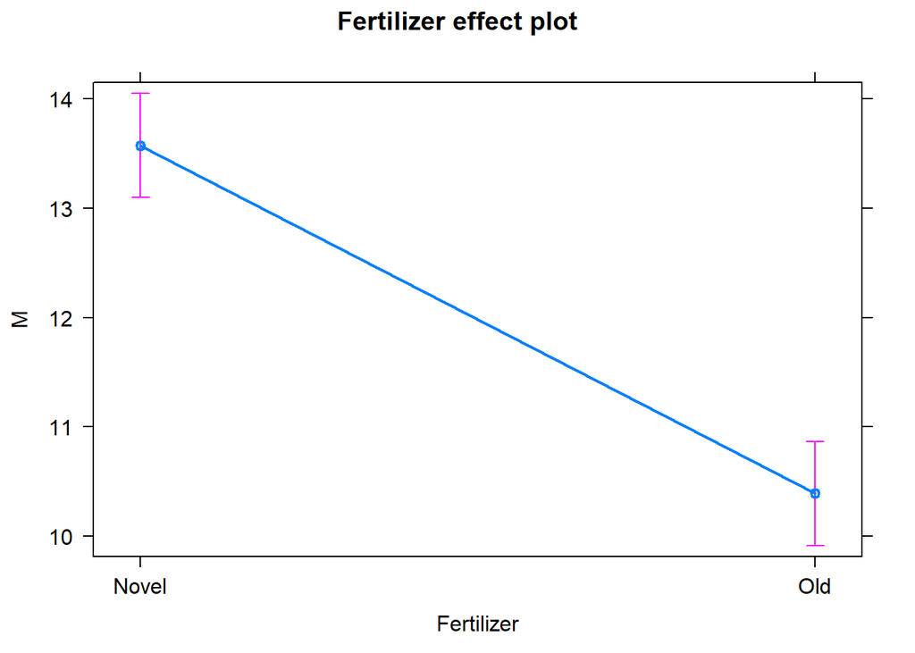

```r
plot(allEffects(strawberries_lmer))
```

**Wnioski:**

Dla nowego nawozu truskawki uzyskują większą masę. Poletka mają pomijalny wpływ. Wyniki są istotnie statystycznie.